# Fundamentos de los métodos estadísticos

## 03-01 Variable aleatoria y distribución de probabilidad

1. Variable aleatoria y distribución de probabilidad
- Variable aleatoria
- Distribución de probabilidad
- Variable aleatoria discreta
- Variable aleatoria continua
- Función de desidad de probabilidad
- Estandarización:

$ U = \frac{X - \mu}{\sigma} $

- Distribución normal estándar:

$ N(0, 1^2) $

2. Valor esperado de la variable aleatoria

$ E(X) = \sum_i x_i p_i = \mu $

$ E(X) = \int_{- \infty}^{\infty} x f(x) dx = \mu $

- Propiedades del valor esperado:

$ E(aX + b) = aE(X) + b $

$ E(aX + bY) = aE(X) + bE(Y) $

3. Propiedades de Varianza
- Varianza poblacional:

$ V(X) = E|(X - \mu)^2| = \sigma^2 $

$ V(X) = E|(x - \mu)^2| = E(X^2) - \mu^2 $

- Aditividad de la varizanza:

$ V(aX+b) = a^2V(X) $

$ V(aX+bY) = a^2V(X) + b^2V(Y)+2Cov(X,Y) $

$ V(aX+bY) = a^2V(X) + b^2V(Y) $ Cuando X e Y son independiente entre si

4. Varianza de la variable aleatoria

$ V(X+Y) = V(X)+V(Y) $ $ V(X-Y)=V(X)+V(Y) $

## Preparación de *Python*

```python
from google.colab import drive
drive.mount('/content/drive/')
```

```python
import os

path = os.getcwd()

try:
  os.chdir(path + '/drive/My Drive/QC_Kentei')
except:
  pass

os.getcwd()
```

```
'/content/drive/My Drive/QC_Kentei'
```

```python
import gspread

from google.colab import auth
auth.authenticate_user()

from google.auth import default
creds, _ = default()

gc = gspread.authorize(creds)
```

```python
!pip install japanize-matplotlib
```

```python
import pandas as pd
import numpy as np

import matplotlib.pyplot as plt
import seaborn as sns
import japanize_matplotlib
```

## 03-02 Distribución uniforme

La distribucón uniforme es una distribución en la que la desnsidad de probabilidad toma un valor constante de $ 1/(b-a) $ en el intervalo (a,b).

$ f(x) = 1/h \qquad (0<x<h) $

$ f(x) = 0 \qquad (x \leq 0, x \geq h) $

$ E(X) = \int_{0}^{h} x \frac{1}{h} dx = \bigl[ \frac{x^2}{2h} \bigr]_{0}^{h} = \frac{h}{2} $

$ E(X^2) = \int_{0}^{h} x^2 \frac{1}{n} dx = \bigl[ \frac{x^2}{3h} \bigr]_0^h = \frac{h^2}{3} $

$ V(X) = E|(X-\mu)^2| = E(X^2) - |E(X)|^2 = \frac{h^2}{3} - (\frac{h}{2})^2 = \frac{h^2}{12} $

$ D(x) = \sqrt{V(X)} = \frac{h}{2 \sqrt{3}}$

## 3.1

確率変数Xが区間(0,4)の一様分布に従うとき、Xの期待値、分散、標準偏差を求めよ。また、確率変数Xが区間(1,3)に入る確率を求めよ。

Sea la variable aleatoria X que sigue una distribución uniforme en el intervalo (0,4), calcule el valor esperado, la varianza y la desviación estándar de X. Además, calcule la probabilidad de que la variable aleatoria X esté en el intervalo (1,3).

```
Valor esperado: 2.00
Varianza: 1.33
Desviación estándar: 1.15
Probabilidad de que la variable aleatoria esté en el intervalo (1,3): 0.50
```

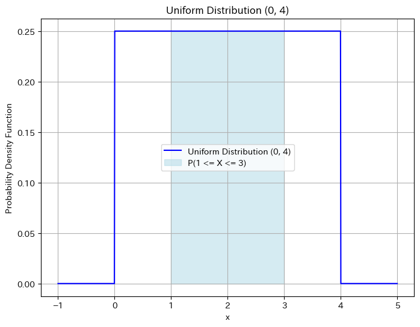

```python
from scipy.stats import uniform

# Parámetros
a, b = 0, 4  # Rango de distribución uniforma (0, 4)

# Valor esperado, Varianza, Desviación estándar
mean = (a + b) / 2
variance = ((b - a) ** 2) / 12
std_dev = np.sqrt(variance)

# Cálculo de la probabilidad de que la variable aleatoria esté en el intervalo (1, 3)
prob_1_to_3 = uniform.cdf(3, loc=a, scale=b-a) - uniform.cdf(1, loc=a, scale=b-a)

print(f"Valor esperado: {mean:.2f}")
print(f"Varianza: {variance:.2f}")
print(f"Desviación estándar: {std_dev:.2f}")
print(f"Probabilidad de que la variable aleatoria esté en el intervalo (1,3): {prob_1_to_3:.2f}")

# Creación de gráficos
x = np.linspace(a - 1, b + 1, 1000)  # Establecer el rango de la gráfica
y = uniform.pdf(x, a, b - a)  # Calcular la PDF

plt.figure(figsize=(8, 6))
plt.plot(x, y, label="Uniform Distribution (0, 4)", color="blue")
plt.fill_between(x, y, where=((x >= 1) & (x <= 3)), color="lightblue", alpha=0.5, label='P(1 <= X <= 3)')
plt.title("Uniform Distribution (0, 4)")
plt.xlabel("x")
plt.ylabel("Probability Density Function")
plt.legend()
plt.grid(True)
plt.show()
```

## 03-03 Distribución exponencial

$ f(x) = 0 \qquad (x<0) $

$ f(x) = \lambda exp(-\lambda x) \qquad (x \geq 0 ) $

$ \mu = \frac{1}{\lambda} $

$ E(X) = \frac{1}{\lambda} = \mu $

$ V(X) = \frac{1}{\lambda^2} = \mu^2 $

## 3.2

部品Qの寿命は、パラメータ $ \lambda=1/100 $ （時間）の指数分布に従っている。この電子部品の寿命が50（時間）から100（時間）であるかくりつを求めよ。また、平均寿命と分散も求めよ。

```
Vida media: 100.00 horas
Varianza: 10000.00 horas²
Probabilidad de vida entre 50 y 100 horas: 0.2387
```

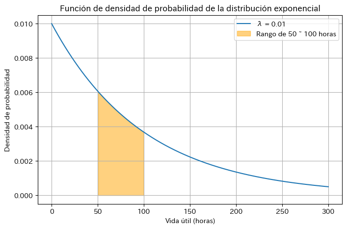

```python
# Parámetros de la distribución
lambda_param = 1 / 100  # Tasa de falla λ = 1/100 horas

# Cálculo de la vida media y la varianza
mean_lifetime = 1 / lambda_param
variance_lifetime = 1 / (lambda_param ** 2)

# Cálculo de la probabilidad de que la vida útil esté entre 50 y 100
probability_50_to_100 = np.exp(-lambda_param * 50) - np.exp(-lambda_param * 100)

# Mostrar resultados
print(f"Vida media: {mean_lifetime:.2f} horas")
print(f"Varianza: {variance_lifetime:.2f} horas²")
print(f"Probabilidad de vida entre 50 y 100 horas: {probability_50_to_100:.4f}")

# Crear gráfico
x = np.linspace(0, 300, 500)  # Rango de 0 a 300 horas
pdf = lambda_param * np.exp(-lambda_param * x)  # Función de densidad de de probabilidad de distribución exponencial

plt.figure(figsize=(8, 5))
plt.plot(x, pdf, label=f"λ = {lambda_param}")
plt.fill_between(x, pdf, where=(x >= 50) & (x <= 100), color='orange', alpha=0.5, label="Rango de 50 ~ 100 horas")
plt.title("Función de densidad de probabilidad de la distribución exponencial")
plt.xlabel("Vida útil (horas)")
plt.ylabel("Densidad de probabilidad")
plt.grid(True)
plt.legend()
plt.show()
```

## 03-04 Distribución bidimensional Covarianza

Distribución bidimensional: Distribución de dos variables aleatorias correspondientes.

Coeficiente de correlación: Cantidad que representa la relación entre dos variables aleatorias

Coeficiente de correlación

$ \rho (X, Y) = \frac{Cov(X, Y)}{\sqrt{V(X) \cdot V(Y) }} = \frac{Cov(X,Y)}{D(X) \cdot D(Y)}$

$ V(aX+bY) = a^2V(X) + b^2V(Y) + 2abCov(X,Y) $

$ \rho (aX +b, cY+d) = \rho (X, Y) $

## 3.3

２種類の加工部品A、Bを別々に製造しこれらを組み合わせ（Aの中にBをはめ込む）部品を作る工程がある。部品Aは外輪で、その内径Xは正規分布 $ N(40,3^2) $に従う、部品Bは軸で、その外形Yは正規分布$ N(30, 1^2) $ に従っている。組み合わせ作業では、Xの大きな部品Aには、Yの大きな部品Bを、Xの小さな部品Aには、Yの小さな部品Yを組み合わせるようにしており、その組み合わせはXとYの母相関係数で0.6であることが分かっている。外輪と軸の隙間である$ Z = X - Y $ の寸法の分散を求めよ。

```python
# Parámetros dados
mu_X = 40   # Media de X（diámetro interior de la pieza A）
sigma_X = np.sqrt(9)  # Desviación estándar de X
mu_Y = 30   # Media de Y（diámetro exterior de la pieza B）
sigma_Y = np.sqrt(1)  # Desviación estándar de Y
rho_XY = 0.6  # Coeficiente de correlación entre X e Y

# Cálculo de la media y la varianza de Z = X - Y
mu_Z = mu_X - mu_Y  # Media de Z
var_Z = sigma_X**2 + sigma_Y**2 - 2 * rho_XY * sigma_X * sigma_Y  # Varianza de Z

# Visualización del resultado
print(f"La varianza de Z = X - Y:  {var_Z:.2f} ")
```

```
La varianza de Z = X - Y:  6.40
```

## 03-05 Ley de grandes números y Teorema central del límite

Ley de los grandes números

La ley de los grandes números establece que, a medida que el número de repeticiones de un experimento aumenta, la media de los resultados obtenidos se acerca al valor esperado o la media teóriaca. Es decir, cuanto más veces se repite un experimento, más probable es que la media de los resultados se eaproxime al valor verdadero que debería esperarse.

Por ejemplo, al lanzar una mondda muchas veces, la frecuentcia relativa de caras y cruces se acercará al valor teórico de 50% para cada uno a medida que el número de lanzamientos aumenta.

Existen dos versiones de la ley de los grandes números: la versión débil y la versión fuerte. La diferencia principal está en el tipo de convergencia que describen, pero ambas indican que la media muestral se estabiliza conforme aumenta el tamaño de la muestra.

Teorema central de límite

El teorema central de límite establece que, independientemente de la distribución de los datos originales, cuando tomamos suficiente muestras de una población, la distribución de la media muestral de esas muestras tenderá a ser una distribución normal (también llamada distribución de Gauss) a medida que el tamaño de la muestra crece. Esto es cierto incluso si los datos originales no siguen una distribución normal.

En otras palabras, si tomamos repetidas muestras de una población y calculamos sus medias, la distribución de esas medias será aproximadamente normal, siempre que el tamaño de las muestras sea lo suficientemente grande, independientemente de cómo se distribuyen los datos originales.

Este teorema es la base de muchas técnicas estadísticas y nos permite usar la distribución normal como aproximación para realizar inferencias sobre una población, incluso cuando no conocemos su distribución exacta.

Ambos conceptos son fundamentales en la teoría de probabilidad, y explican por qué las distribuciones de los promedios tienden a normalizarse y cómo se puede prever el comportamiento de los resultados en experimentos repetidos.